# Image classification on CIFAR-10

David Galera

21-04-2023

# Preparació de dades

Importació de llibreries

```python
from fastai.vision.all import *
```

```python
from fastai.callback.hook import *
```

```python
from fastai.callback.fp16 import *
```

```python
def get_default_device():
    """Pick GPU if available, else CPU"""
    if torch.cuda.is_available():
        return torch.device('cuda')
    else:
        return torch.device('cpu')
```

```python
device = get_default_device()
device
```

```
device(type='cuda')
```

```python
from google.colab import drive
drive.mount('/content/drive')
```

Descomprimim les imatges d'entrenament i validació a l'arrel del Notebook

```python
!unzip '/content/drive/MyDrive/CIFAR/dataset_CIFAR10' -d '/content/data'
```

```python
#!unzip '/content/drive/MyDrive/Advanced ML/CIFAR/dataset_CIFAR10' -d '/content/data'
```

```python
path = Path('/content/data')
```

```python
data = DataBlock(
        blocks=(ImageBlock, CategoryBlock), get_items=get_image_files,
        splitter=GrandparentSplitter(train_name='train', valid_name='validation'),
        get_y=parent_label,
        item_tfms=Resize(96),#augmentem la resolució a 96x96
        batch_tfms=[*aug_transforms(size=32, min_scale=0.8,max_zoom=1.2),#retallem imatges a la mida 32x32
                    Normalize.from_stats(*imagenet_stats)],#normalitzem imatges
    )
data.summary(path)
```

[output not shown]

[output cut: 30 more lines]

[output not shown]

Instanciem els *dataloaders* amb una mida del batch de 64.

```python
dls = data.dataloaders(path, bs=64)
```

```python
print(len(dls))
dls.vocab #encoding del target
```

```
2
```

```
['airplane', 'automobile', 'bird', 'cat', 'deer', 'dog', 'frog', 'horse', 'ship', 'truck']
```

[figure not shown]

```python
dls.show_batch(max_n=4, figsize=(4,4))
```

# Resnet34

Instanciem el vision learner amb l'arquitectura resnet34

```python
learner = vision_learner(dls,resnet34, metrics=[accuracy,error_rate],cbs=ActivationStats(with_hist=True)).to_fp16()
```

Fem un primer entrenament a la xarxa emprant *fine_tuning*, on les 3 primeres èpoques les capes preentrenades estan congelades i posteriorment es descongela la xarxa sencera i s'entrena 6 èpoques més.

```python
learner.fine_tune(freeze_epochs=3, epochs=6)
```

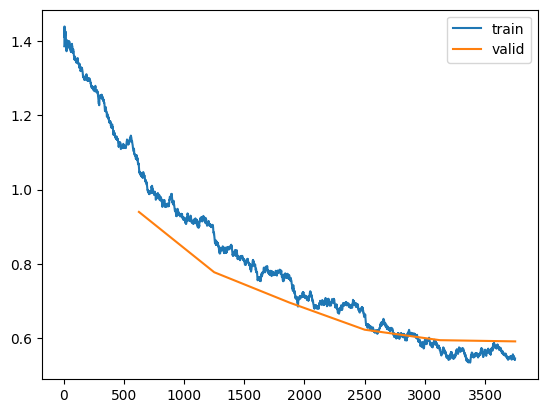

```python
learner.recorder.plot_loss()
```

Al voltant del batch 2500, la loss de validació perd força en la caiguda, la d'entrenament també però en menor mesura.

Fem una ullada a les activacions de la penúltima capa. El percentatge d'activacions properes a 0 es redueix lleugerament a mesura que acumula entrenament.

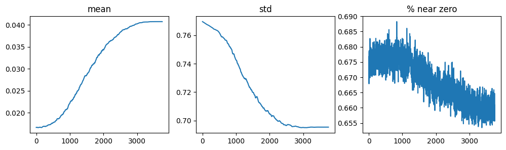

```python
learner.activation_stats.plot_layer_stats(-2)
```

Learning/momentum rate per batch

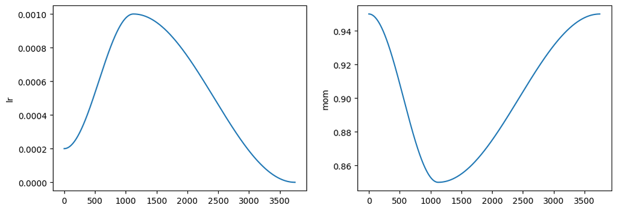

```python
learner.recorder.plot_sched()
```

Copia de seguretat del model:

```python
learner.export('resnet34_1.pkl')
```

Invoquem el mètode learning rate finder per trobar un interval de learning rate amb loss estable.

```
SuggestedLRs(valley=0.00010964782268274575)
```

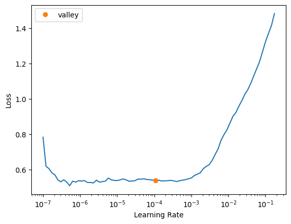

```python
learner.lr_find()
```

Entrenem la xarxa 5 èpoques més emprant un **discriminative learning rate**. Així, el lr varia éssent menor en les primeres capes de la xarxa (preentrenades) i augmentant progressivament a mesura que s'aprofundeix en les capes de la xarxa.

```python
learner.fit_one_cycle(5, lr_max=slice(1e-6, 3e-4))
```

| epoch | train_loss | valid_loss | accuracy | error_rate | time |
| --- | --- | --- | --- | --- | --- |
| 0 | 0.550229 | 0.597995 | 0.794500 | 0.205500 | 03:45 |
| 1 | 0.535170 | 0.584816 | 0.795900 | 0.204100 | 03:38 |
| 2 | 0.494472 | 0.577232 | 0.804100 | 0.195900 | 03:36 |
| 3 | 0.485739 | 0.580298 | 0.800100 | 0.199900 | 03:34 |
| 4 | 0.505086 | 0.586395 | 0.797500 | 0.202500 | 03:34 |

La loss de validació i l'accuracy amb prou feines milloren.

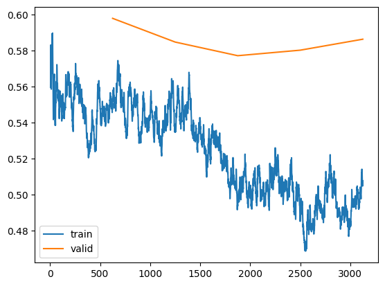

```python
learner.recorder.plot_loss()
```

A la gràfica s'observa com hi ha un desacoplament entre la loss d'entrenament i la de validació, això indica que el model no està entrenant bé sinó que està memoritzant imatges.

```python
learner.export('resnet34_2.pkl')
```

Apliquem tècniques de data augmentation, mantenim la resolució de 96x96 per imatge però augmentem la mida de la imatge retallada a 64.

```python
data2 = data.new(item_tfms=Resize(96), batch_tfms=[*aug_transforms(size=64, min_scale=0.8, max_zoom=1.1), Normalize.from_stats(*imagenet_stats)])
```

```python
dls2 = data2.dataloaders(path, bs=64)
```

```python
learner.dls = dls2
```

Tornem a calcular el learning rate

```
SuggestedLRs(valley=0.00013182566908653826)
```

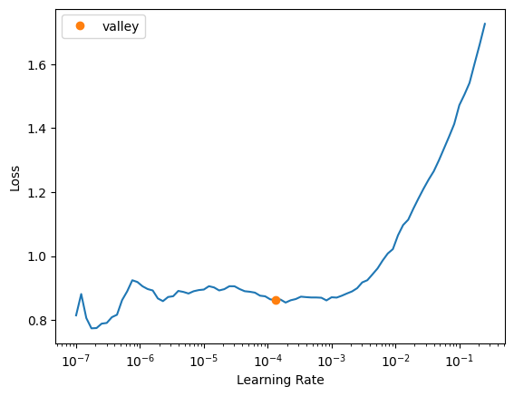

```python
learner.lr_find()
```

Entrenem la xarxa 10 èpoques més amb fit_one_cycle passant al paràmetre *lr_max* un *slice* amb l'interval de learning rate màxim en les primeres i últimes capes.

```python
learner.fit_one_cycle(10, lr_max=slice(2e-6, 1e-4))
```

60.00% [6/10 49:54<33:16]

[output not shown]

91.20% [570/625 06:05<00:35 0.3654]

| epoch | train_loss | valid_loss | accuracy | error_rate | time |
| --- | --- | --- | --- | --- | --- |
| 0 | 0.799928 | 0.686747 | 0.760800 | 0.239200 | 08:36 |
| 1 | 0.632634 | 0.532282 | 0.813900 | 0.186100 | 08:28 |
| 2 | 0.539021 | 0.470937 | 0.839700 | 0.160300 | 08:10 |
| 3 | 0.474070 | 0.431860 | 0.849600 | 0.150400 | 08:11 |
| 4 | 0.431883 | 0.415190 | 0.857100 | 0.142900 | 08:13 |
| 5 | 0.409213 | 0.396781 | 0.861800 | 0.138200 | 08:13 |
| 6 | 0.366935 | 0.395546 | 0.862500 | 0.137500 | 08:11 |
| 7 | 0.352300 | 0.384290 | 0.867800 | 0.132200 | 08:05 |
| 8 | 0.333253 | 0.388268 | 0.867400 | 0.132600 | 08:01 |
| 9 | 0.336894 | 0.385965 | 0.866800 | 0.133200 | 07:56 |

El temps d'entrenament creix a més del doble, conseqüencia de doblar la mida dels retalls.

```python
learner.export('resnet34_3.pkl')
```

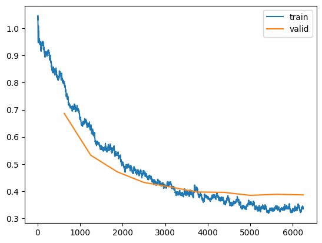

```python
learner.recorder.plot_loss()
```

S'observa com ambdós pèrdues disminueixen a un ritme similar inicialment però la loss de validació frena el ritme fins a pràcticament estacionar-se a partir de la meitat de l'entrenament.

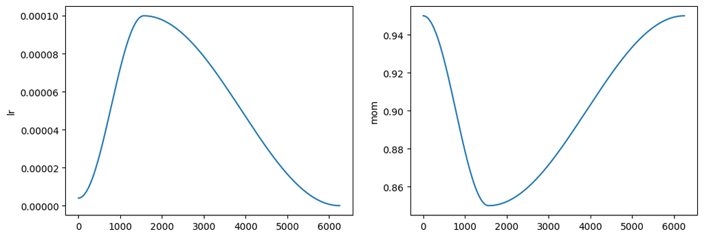

```python
learner.recorder.plot_sched()
```

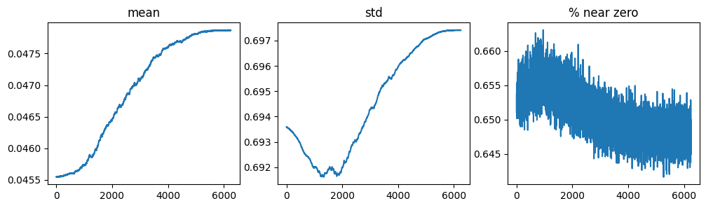

```python
learner.activation_stats.plot_layer_stats(-2)
```

Les activacions properes a 0 continuen disminuint lleugerament.

```python
learner2 = load_learner('/content/resnet34_3.pkl', cpu=False)
```

Apliquem un resizing de 128x128 i retallem a 96x96.

```python
data3 = data.new(item_tfms=Resize(128), batch_tfms=[*aug_transforms(size=96, min_scale=0.8,max_zoom=1.2,max_lighting=0.4),
                                                    Normalize.from_stats(*imagenet_stats)]
                )
```

```python
dls3 = data3.dataloaders(path, bs=64)
```

```python
learner2.dls = dls3
```

```
SuggestedLRs(valley=7.585775892948732e-05)
```

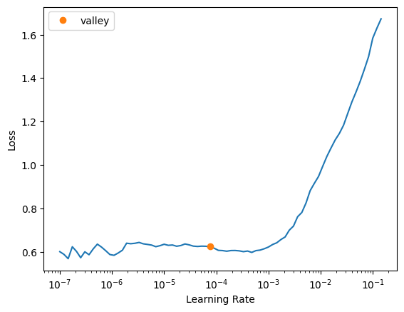

```python
learner2.lr_find()
```

Fem una primera prova entrenant 3 èpoques:

```python
learner2.fit_one_cycle(3, lr_max=slice(1e-6, 3e-4))
```

| epoch | train_loss | valid_loss | accuracy | error_rate | time |
| --- | --- | --- | --- | --- | --- |
| 0 | 0.510129 | 0.401182 | 0.861900 | 0.138100 | 16:42 |
| 1 | 0.426255 | 0.363464 | 0.876000 | 0.124000 | 16:37 |
| 2 | 0.407743 | 0.351068 | 0.880000 | 0.120000 | 16:51 |

S'aprecia com els temps d'entrenament han augmentat al doble vers l'entrenament anterior.

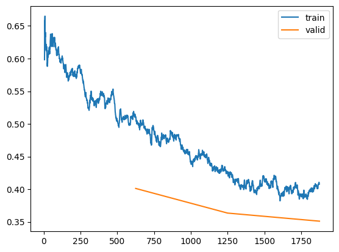

```python
learner2.recorder.plot_loss()
```

A priori la xarxa està aprenent sense mostrar signes d'*overfitting*.

```python
learner2.export('resnet34_4.pkl')
```

```python
learner3 = load_learner('/content/drive/MyDrive/resnet34_4.pkl', cpu=False)
```

```python
learner3.dls = dls3
```

```python
learner3.dls.to(device='cuda')
learner3.model.to(device='cuda')
```

Recalculem el learning rate.

```
SuggestedLRs(valley=3.0199516913853586e-05)
```

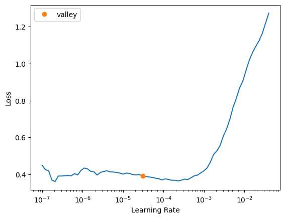

```python
learner3.lr_find()
```

```python
learner3.fit_one_cycle(7, lr_max=slice(1e-6, 3e-4))
```

| epoch | train_loss | valid_loss | accuracy | error_rate | time |
| --- | --- | --- | --- | --- | --- |
| 0 | 0.367875 | 0.348541 | 0.879200 | 0.120800 | 17:36 |
| 1 | 0.375715 | 0.332455 | 0.885900 | 0.114100 | 17:13 |
| 2 | 0.338177 | 0.321694 | 0.891100 | 0.108900 | 17:31 |
| 3 | 0.315589 | 0.316373 | 0.892200 | 0.107800 | 17:33 |
| 4 | 0.292972 | 0.312402 | 0.895100 | 0.104900 | 17:08 |
| 5 | 0.257325 | 0.307201 | 0.896800 | 0.103200 | 17:35 |
| 6 | 0.248001 | 0.307965 | 0.897000 | 0.103000 | 17:17 |

Hi ha correlació entre la valid_loss i l'error_rate durant tot l'entrenament.

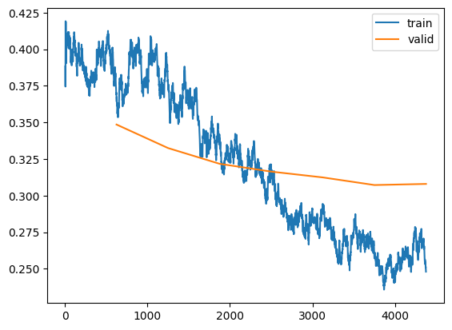

```python
learner3.recorder.plot_loss()
```

S'observa un pendent diferent en les dues trajectòries, la loss de validació frena la caiguda i s'estaciona. Mentre que la d'entrenament continua caient, el model mostra signes d'*overfitting*.

Guardem només els paràmetres del model:

```python
learner3.save('phase-5')
```

```
Path('models/phase-5.pth')
```

Instanciem un learner canviant la loss function a utilitzar amb la tècnica de MixUp, aquesta tècnica agafa dues imatges del conjunt d’entrenament (que poden ser d’una mateixa classe o no) i en crea una combinació lineal utilitzada per entrenar el model.

```python
learner = vision_learner(dls3, resnet34,
                      metrics=[accuracy,error_rate],
                      loss_func=LabelSmoothingCrossEntropy(),
                      cbs=MixUp()).to_fp16()
```

Descongelem el model preentrenat i carreguem paràmetres de la xarxa preentrenada previament.

```python
learner.unfreeze()
learner.load('/content/drive/MyDrive/phase-5')
learner.unfreeze()
```

```
SuggestedLRs(valley=0.00019054606673307717)
```

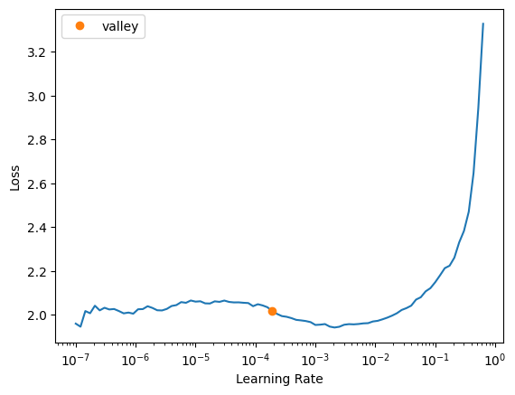

```python
learner.lr_find()
```

Entrenem el model 50 èpoques amb la tècnica MixUp:

```python
learner.fit_one_cycle(50, lr_max=slice(1e-6,2e-3))
```

| epoch | train_loss | valid_loss | accuracy | error_rate | time |
| --- | --- | --- | --- | --- | --- |
| 0 | 1.268884 | 0.808474 | 0.893200 | 0.106800 | 02:30 |
| 1 | 1.242209 | 0.790137 | 0.893800 | 0.106200 | 02:03 |
| 2 | 1.231355 | 0.776175 | 0.895700 | 0.104300 | 02:05 |
| 3 | 1.225317 | 0.773435 | 0.894300 | 0.105700 | 02:09 |
| 4 | 1.208570 | 0.763762 | 0.899100 | 0.100900 | 02:12 |
| 5 | 1.200364 | 0.760336 | 0.896900 | 0.103100 | 02:15 |
| 6 | 1.211545 | 0.760503 | 0.896600 | 0.103400 | 02:17 |
| 7 | 1.193988 | 0.752411 | 0.898900 | 0.101100 | 02:01 |
| 8 | 1.195594 | 0.763940 | 0.894800 | 0.105200 | 02:01 |
| 9 | 1.176591 | 0.746642 | 0.900100 | 0.099900 | 01:59 |
| 10 | 1.164286 | 0.744689 | 0.903200 | 0.096800 | 01:57 |
| 11 | 1.170024 | 0.741013 | 0.903000 | 0.097000 | 01:56 |
| 12 | 1.154586 | 0.732956 | 0.906900 | 0.093100 | 02:02 |
| 13 | 1.141009 | 0.744847 | 0.904400 | 0.095600 | 01:57 |
| 14 | 1.127672 | 0.727557 | 0.908200 | 0.091800 | 01:57 |
| 15 | 1.120908 | 0.732661 | 0.906200 | 0.093800 | 01:57 |
| 16 | 1.106844 | 0.721615 | 0.912700 | 0.087300 | 01:57 |
| 17 | 1.109513 | 0.721273 | 0.912100 | 0.087900 | 01:59 |
| 18 | 1.096418 | 0.719479 | 0.916000 | 0.084000 | 01:59 |
| 19 | 1.089432 | 0.719435 | 0.913100 | 0.086900 | 01:58 |
| 20 | 1.085954 | 0.719160 | 0.911200 | 0.088800 | 01:55 |
| 21 | 1.072541 | 0.716586 | 0.917700 | 0.082300 | 01:56 |
| 22 | 1.075611 | 0.719648 | 0.914900 | 0.085100 | 01:56 |
| 23 | 1.063298 | 0.711557 | 0.917200 | 0.082800 | 01:56 |
| 24 | 1.063945 | 0.704481 | 0.919900 | 0.080100 | 01:57 |
| 25 | 1.080790 | 0.706308 | 0.920900 | 0.079100 | 01:56 |
| 26 | 1.065808 | 0.703239 | 0.921700 | 0.078300 | 01:55 |
| 27 | 1.054579 | 0.705486 | 0.921900 | 0.078100 | 01:55 |
| 28 | 1.042021 | 0.701612 | 0.919800 | 0.080200 | 01:55 |
| 29 | 1.054804 | 0.700986 | 0.922400 | 0.077600 | 01:55 |
| 30 | 1.034933 | 0.698886 | 0.923600 | 0.076400 | 01:55 |
| 31 | 1.025139 | 0.702596 | 0.922700 | 0.077300 | 01:56 |
| 32 | 1.040333 | 0.699457 | 0.922900 | 0.077100 | 01:55 |
| 33 | 1.041241 | 0.696220 | 0.923900 | 0.076100 | 01:55 |
| 34 | 1.027392 | 0.695653 | 0.924900 | 0.075100 | 01:54 |
| 35 | 1.035752 | 0.698115 | 0.924600 | 0.075400 | 01:55 |
| 36 | 1.035180 | 0.695975 | 0.923800 | 0.076200 | 01:55 |
| 37 | 1.019700 | 0.690552 | 0.926800 | 0.073200 | 01:55 |
| 38 | 1.028877 | 0.692345 | 0.925300 | 0.074700 | 02:01 |
| 39 | 1.029715 | 0.690804 | 0.926800 | 0.073200 | 02:07 |
| 40 | 1.028030 | 0.691982 | 0.926600 | 0.073400 | 02:11 |
| 41 | 1.015141 | 0.690993 | 0.925700 | 0.074300 | 02:08 |
| 42 | 1.027894 | 0.692262 | 0.926200 | 0.073800 | 01:57 |
| 43 | 1.021537 | 0.691102 | 0.927600 | 0.072400 | 01:56 |
| 44 | 1.011707 | 0.690448 | 0.927700 | 0.072300 | 01:56 |
| 45 | 1.017083 | 0.689746 | 0.927700 | 0.072300 | 01:56 |
| 46 | 1.013937 | 0.689326 | 0.928100 | 0.071900 | 01:56 |
| 47 | 1.014206 | 0.688057 | 0.929300 | 0.070700 | 01:56 |
| 48 | 1.015616 | 0.690307 | 0.928500 | 0.071500 | 01:57 |
| 49 | 1.014669 | 0.689802 | 0.927600 | 0.072400 | 01:58 |

Aconseguim una *accuracy* propera al 93%.

```python
learner.export('resnet34_final.pkl')
```

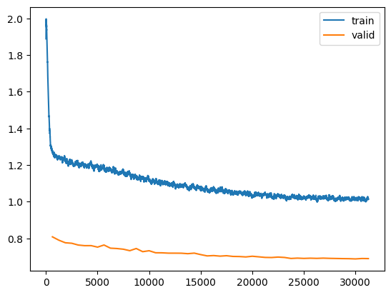

```python
learner.recorder.plot_loss()
```

Observem com al aplicar la tècnica de MixUp a les imatges el model es mostra menys confiat al realitzar les prediccions, el que fa augmentar la loss quan les prediccions són correctes. A més a més, la loss d’entrenament és superior a la de validació en totes les èpoques, així doncs, mitjançant el MixUp dotem al model d’un alt grau de regularització i s’elimina qualsevol possibilitat d’overfitting.

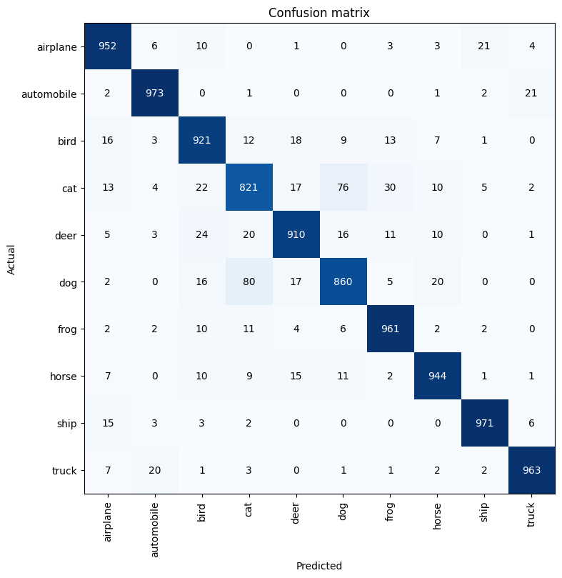

```python
interp = ClassificationInterpretation.from_learner(learner)
interp.plot_confusion_matrix(figsize=(8,8))
```

Les classes que costen més de classificar al model són la de gat i la de gos amb el 82.1% i el 86% d’encerts respectivament. Per contra, les classes que millor classifica són la d’automobil i la de vaixell, amb més del 97% d’encerts.

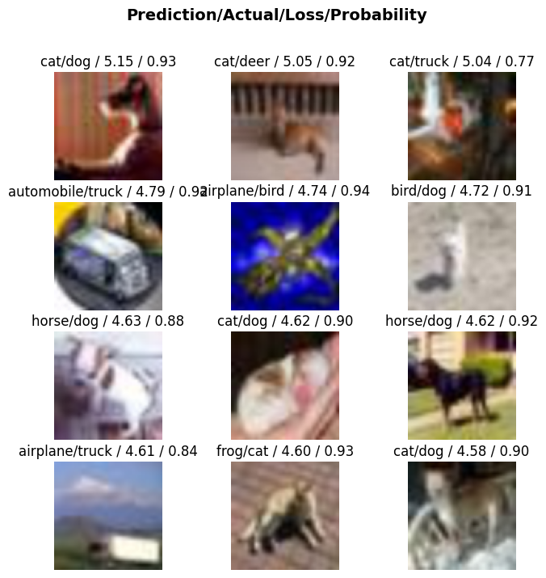

```python
interp.plot_top_losses(12, nrows=4, figsize=(8, 8))
```

# Resnet50

Instanciem els *dataloaders* amb canviant la mida del batch a 128.

```python
dls = data.dataloaders(path, bs=128)
```

```python
learner = vision_learner(dls,resnet50, metrics=[accuracy,error_rate],cbs=ActivationStats(with_hist=True)).to_fp16()
```

Fem un primer entrenament a la xarxa emprant *fine_tuning*, on les 3 primeres èpoques les capes preentrenades estan congelades i posteriorment es descongela la xarxa sencera i s'entrena 10 èpoques més.

```python
learner.fine_tune(freeze_epochs=3, epochs=10)
```

| epoch | train_loss | valid_loss | accuracy | error_rate | time |
| --- | --- | --- | --- | --- | --- |
| 0 | 2.214438 | 1.674736 | 0.437000 | 0.563000 | 07:14 |
| 1 | 1.700533 | 1.450217 | 0.493900 | 0.506100 | 06:38 |
| 2 | 1.476050 | 1.295570 | 0.558300 | 0.441700 | 06:34 |

90.00% [9/10 1:01:02<06:46]

[output not shown]

48.08% [150/312 02:35<02:47 0.3259]

| epoch | train_loss | valid_loss | accuracy | error_rate | time |
| --- | --- | --- | --- | --- | --- |
| 0 | 1.126115 | 0.963054 | 0.656900 | 0.343100 | 06:54 |
| 1 | 0.899293 | 0.790054 | 0.723400 | 0.276600 | 06:46 |
| 2 | 0.752662 | 0.733900 | 0.755600 | 0.244400 | 06:44 |
| 3 | 0.663406 | 0.641830 | 0.779600 | 0.220400 | 06:50 |
| 4 | 0.573282 | 0.594380 | 0.798900 | 0.201100 | 06:55 |
| 5 | 0.508006 | 0.555550 | 0.810500 | 0.189500 | 06:52 |
| 6 | 0.429835 | 0.547897 | 0.817400 | 0.182600 | 06:47 |
| 7 | 0.373451 | 0.536302 | 0.823900 | 0.176100 | 06:34 |
| 8 | 0.339026 | 0.530442 | 0.829300 | 0.170700 | 06:36 |
| 9 | 0.316208 | 0.526164 | 0.829900 | 0.170100 | 06:30 |

Observem com els temps d'entrenament augmenten fins al doble que els de l'arquitectura resnet34 al entrenar una xarxa de més capacitat.

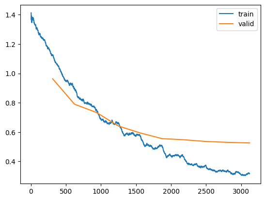

```python
learner.recorder.plot_loss()
```

La loss de validació s’assimila a la de la primera etapa de l’experiment amb resnet34, la d’entrenament cau amb més força i l’accuracy aconseguit al finalitzar l’entrenament és superior, del 83%.

Mostrem el learning rate i momentum per batch.

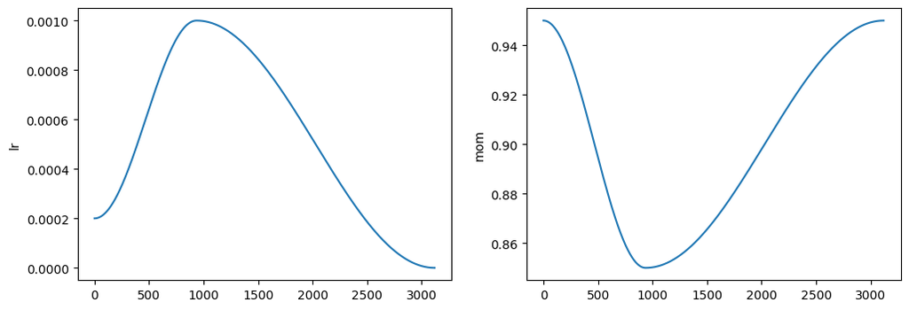

```python
learner.recorder.plot_sched()
```

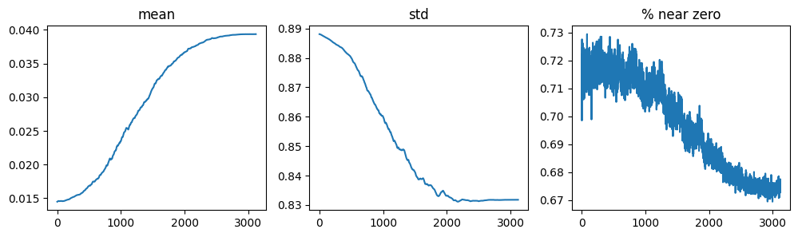

```python
learner.activation_stats.plot_layer_stats(-2)
```

El percentatge d'activacions proper a 0 és superior a la xarxa anterior. Al tenir la xarxa actual més capacitat, això no vol dir que el número total d'activacions diferents de 0 sigui menor.

```python
learner.export('resnet50_1.pkl')
```

```python
learner = load_learner('/content/drive/MyDrive/resnet50_1.pkl', cpu=False)
```

Augmentem la mida dels retalls a 64.

```python
data2 = data.new(item_tfms=Resize(96), batch_tfms=[*aug_transforms(size=64, min_scale=0.8, max_zoom=1.1), Normalize.from_stats(*imagenet_stats)])
```

```python
dls2 = data2.dataloaders(path, bs=128)
```

```python
learner.dls = dls2
```

Tornem a calcular el learning rate

```
SuggestedLRs(valley=0.00015848931798245758)
```

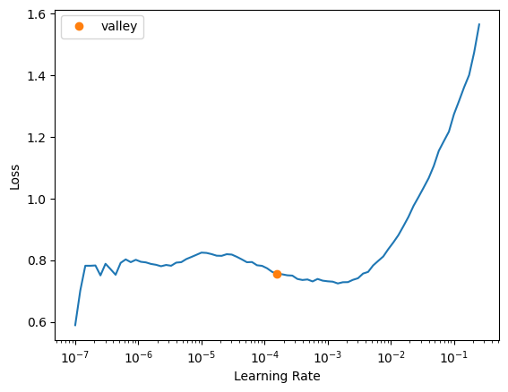

```python
learner.lr_find()
```

Entrenem la xarxa 10 èpoques més amb *fit_one_cycle* fent ús de *discriminative learning rate*.

```python
learner.fit_one_cycle(10, lr_max=slice(2e-6, 2e-4))
```

| epoch | train_loss | valid_loss | accuracy | error_rate | time |
| --- | --- | --- | --- | --- | --- |
| 0 | 0.672322 | 0.588279 | 0.796400 | 0.203600 | 23:16 |
| 1 | 0.506126 | 0.458093 | 0.842000 | 0.158000 | 23:09 |
| 2 | 0.430870 | 0.392269 | 0.863100 | 0.136900 | 23:10 |
| 3 | 0.369234 | 0.370100 | 0.871200 | 0.128800 | 23:29 |
| 4 | 0.326310 | 0.361640 | 0.874100 | 0.125900 | 24:00 |
| 5 | 0.277811 | 0.350789 | 0.879200 | 0.120800 | 23:49 |
| 6 | 0.249557 | 0.344200 | 0.881500 | 0.118500 | 23:11 |
| 7 | 0.239247 | 0.343882 | 0.881600 | 0.118400 | 23:19 |
| 8 | 0.227238 | 0.339757 | 0.882900 | 0.117100 | 23:07 |
| 9 | 0.219545 | 0.339860 | 0.882700 | 0.117300 | 23:38 |

```python
learner.export('resnet50_2.pkl')
```

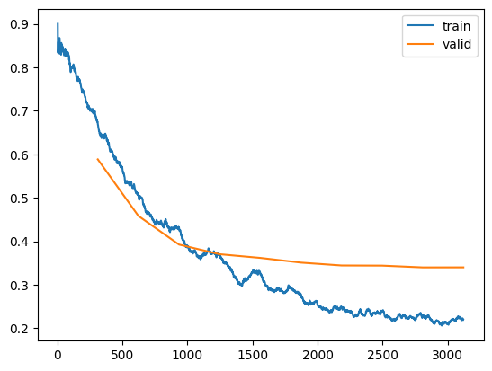

```python
learner.recorder.plot_loss()
```

S'observa com ambdós pèrdues disminueixen a un ritme similar fins al batch 1000 aproximadament, a partir d'aquest punt la loss de validació frena el ritme de caiguda fins a pràcticament estacionar-se a partir de l'últime terç d'entrenament.

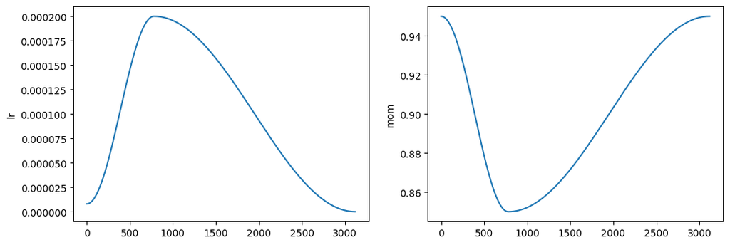

```python
learner.recorder.plot_sched()
```

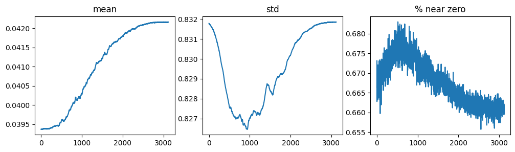

```python
learner.activation_stats.plot_layer_stats(-2)
```

S'observa com el número total d'activacions properes a zero continua disminuint, comportament idèntic al de l'experiment anterior.

Apliquem un resizing a 128x128 i retallem a 96x96.

```python
data3 = data.new(item_tfms=Resize(128), batch_tfms=[*aug_transforms(size=96, min_scale=0.8,max_zoom=1.2,max_lighting=0.4),
                                                    Normalize.from_stats(*imagenet_stats)]
                )
```

```python
dls3 = data3.dataloaders(path, bs=128)
```

```python
learner.dls = dls3
```

```python
learner.dls.to(device='cuda')
learner.model.to(device='cuda')
```

[output not shown]

[output cut: 135 more lines]

[output not shown]

```
SuggestedLRs(valley=9.120108734350652e-05)
```

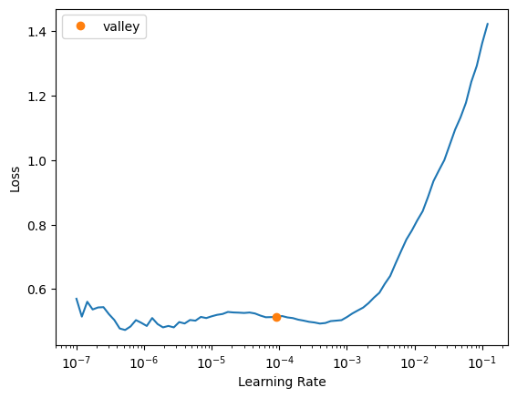

```python
learner.lr_find()
```

```python
learner.fit_one_cycle(5, lr_max=slice(1e-6, 4e-4))
```

| epoch | train_loss | valid_loss | accuracy | error_rate | time |
| --- | --- | --- | --- | --- | --- |
| 0 | 0.438796 | 0.369146 | 0.874000 | 0.126000 | 50:05 |
| 1 | 0.378178 | 0.332743 | 0.886600 | 0.113400 | 48:55 |
| 2 | 0.331463 | 0.310287 | 0.895200 | 0.104800 | 48:25 |
| 3 | 0.283198 | 0.303825 | 0.895700 | 0.104300 | 48:11 |
| 4 | 0.278306 | 0.307634 | 0.897400 | 0.102600 | 48:04 |

Al entrenar amb uns temps tant alts, es fa inviable entrenar més èpoques amb les GPUs públiques de Google Colab. El temps total d'aquest entrenament supera les 4 hores. Hi ha correlació entre la valid_loss i l'error_rate durant tot l'entrenament. L'accuracy final es molt similar a la d'aquest mateix punt en l'experiment anterior, però havent entrenat la meitat d'èpoques.

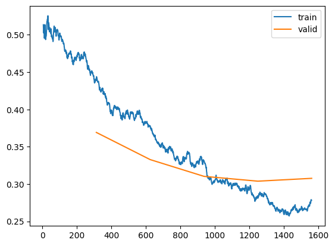

```python
learner.recorder.plot_loss()
```

Els resultats de la loss segueixen la línia de les dues etapes anteriors, el model entrena bé durant la primera fase d’entrenament però a partir del batch 1000 és incapaç de continuar disminuïnt l’error o la validation loss però si la training loss, mostrant signes d’*overfitting*.

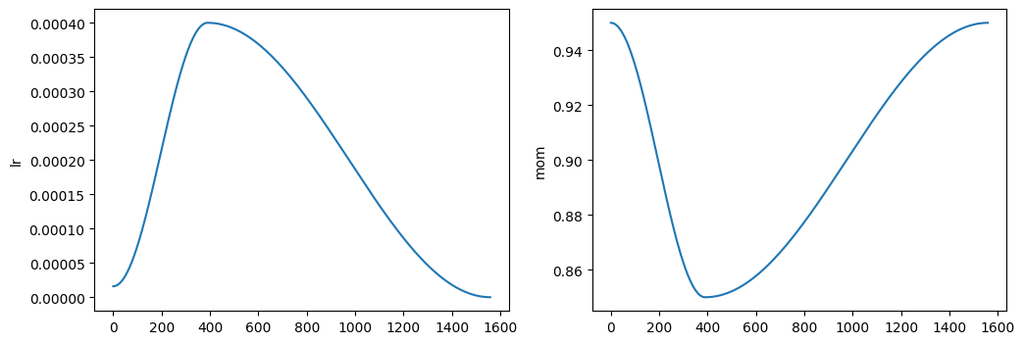

```python
learner.recorder.plot_sched()
```